## By Xiaodong Gu (xgu60)

*Note: This project involves getting data ready for analysis and doing some preliminary investigations. Project 2 will involve modeling and predictions, and will be released at a later date. Both projects will have equal weightage towards your grade.*

# Data

In this project, you will explore a dataset that contains information about movies, including ratings, budget, gross revenue and other attributes. It was prepared by Dr. Guy Lebanon, and here is his description of the dataset:

> The file [`movies_merged`](https://s3.amazonaws.com/content.udacity-data.com/courses/gt-cs6242/project/movies_merged) contains a dataframe with the same name that has 40K rows and 39 columns. Each row represents a movie title and each column represents a descriptor such as `Title`, `Actors`, and `Budget`. I collected the data by querying IMDbâs API (see [www.omdbapi.com](http://www.omdbapi.com/)) and joining it with a separate dataset of movie budgets and gross earnings (unknown to you). The join key was the movie title. This data is available for personal use, but IMDbâs terms of service do not allow it to be used for commercial purposes or for creating a competing repository.

# Objective

Your goal is to investigate the relationship between the movie descriptors and the box office success of movies, as represented by the variable `Gross`. This task is extremely important as it can help a studio decide which titles to fund for production, how much to bid on produced movies, when to release a title, how much to invest in marketing and PR, etc. This information is most useful before a title is released, but it is still very valuable after the movie is already released to the public (for example it can affect additional marketing spend or how much a studio should negotiate with on-demand streaming companies for âsecond windowâ streaming rights).

# Instructions

When you execute code within the notebook, the results appear beneath the code. Try executing this chunk by clicking the *Run* button within the chunk or by placing your cursor inside it and pressing *Cmd+Shift+Enter*.

```r
x = 1:10
print(x^2)
```

```
##  [1]   1   4   9  16  25  36  49  64  81 100
```

Plots appear inline too:

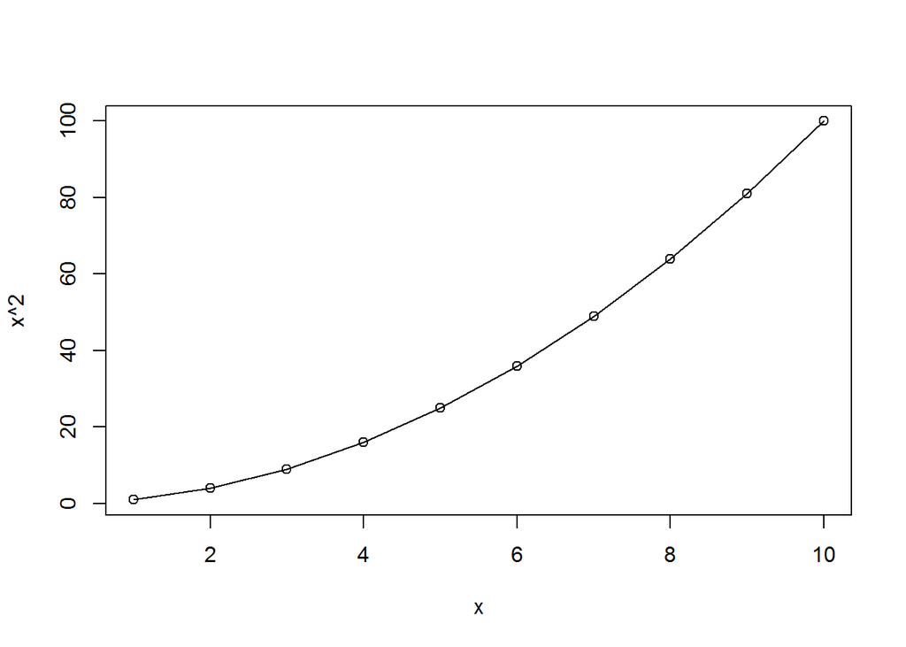

```r
plot(x, x^2, 'o')
```

Please complete the tasks below and submit this R Markdown file (as **pr1.Rmd**) as well as a PDF export of it (as **pr1.pdf**). Both should contain all the code, output, plots and written responses for each task.

# Setup

## Load data

Make sure you’ve downloaded the [`movies_merged`](https://s3.amazonaws.com/content.udacity-data.com/courses/gt-cs6242/project/movies_merged) file and it is in the current working directory. Now load it into memory:

```r
load('movies_merged')
```

This creates an object of the same name (`movies_merged`). For convenience, you can copy it to `df` and start using it:

```r
df = movies_merged
cat("Dataset has", dim(df)[1], "rows and", dim(df)[2], "columns", end="\n", file="")
```

```
## Dataset has 40789 rows and 39 columns
```

```r
colnames(df)
```

```
##  [1] "Title"             "Year"              "Rated"
##  [4] "Released"          "Runtime"           "Genre"
##  [7] "Director"          "Writer"            "Actors"
## [10] "Plot"              "Language"          "Country"
## [13] "Awards"            "Poster"            "Metascore"
## [16] "imdbRating"        "imdbVotes"         "imdbID"
## [19] "Type"              "tomatoMeter"       "tomatoImage"
## [22] "tomatoRating"      "tomatoReviews"     "tomatoFresh"
## [25] "tomatoRotten"      "tomatoConsensus"   "tomatoUserMeter"
## [28] "tomatoUserRating"  "tomatoUserReviews" "tomatoURL"
## [31] "DVD"               "BoxOffice"         "Production"
## [34] "Website"           "Response"          "Budget"
## [37] "Domestic_Gross"    "Gross"             "Date"
```

## Load R packages

Load any R packages that you will need to use. You can come back to this chunk, edit it and re-run to load any additional packages later.

```r
library(ggplot2)
library(GGally)
library(reshape)
```

If you are loading any non-standard packages (ones that have not been discussed in class or explicitly allowed for this project), please mention them below. Include any special instructions if they cannot be installed using the regular `install.packages('<pkg name>')` command.

**Non-standard packages used**: None

# Tasks

Each task below is worth **10** points, and is meant to be performed sequentially, i.e. do step 2 after you have processed the data as described in step 1. Total points: **100**

Complete each task by implementing code chunks as described by `TODO` comments, and by responding to questions (“**Q**:”) with written answers (“**A**:”). If you are unable to find a meaningful or strong relationship in any of the cases when requested, explain why not by referring to appropriate plots/statistics.

It is OK to handle missing values below by omission, but please omit as little as possible. It is worthwhile to invest in reusable and clear code as you may need to use it or modify it in project 2.

## 1. Remove non-movie rows

The variable `Type` captures whether the row is a movie, a TV series, or a game. Remove all rows from `df` that do not correspond to movies.

```r
# TODO: Remove all rows from df that do not correspond to movies
df = df[df$Type == "movie",]
nrow(df)
```

```
## [1] 40000
```

**Q**: How many rows are left after removal? *Enter your response below.*

**A**: 40000

## 2. Process `Runtime` column

The variable `Runtime` represents the length of the title as a string. Write R code to convert it to a numeric value (in minutes) and replace `df$Runtime` with the new numeric column.

```r
# TODO: Replace df$Runtime with a numeric column containing the runtime in minutes
#df$Runtime = strtoi(do.call(rbind, strsplit(df$Runtime, " ", fixed = TRUE))[, 1])
calTime = function(str){
  if(str == "N/A"){
    return(NA)
  }

  strList = unlist(strsplit(str, " "))
  h.pos = grep("h", strList)
  if(!is.na(h.pos[1])){
    h.num = as.numeric(strList[h.pos[1] - 1])
  } else{
    h.num = 0
  }
  min.pos = grep("min", strList)
  if(!is.na(min.pos[1])){
    min.num = as.numeric(strList[min.pos[1] - 1])
  } else{
    min.num = 0
  }
  return (h.num * 60 + min.num)
}

df$Runtime = mapply(calTime, df$Runtime)
```

Now investigate the distribution of `Runtime` values and how it changes over years (variable `Year`, which you can bucket into decades) and in relation to the budget (variable `Budget`). Include any plots that illustrate.

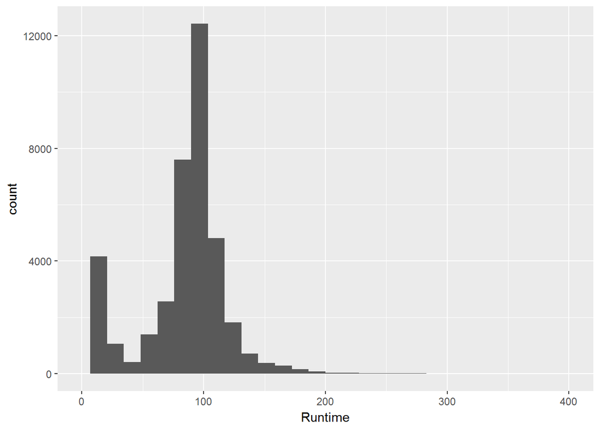

```r
# TODO: Investigate the distribution of Runtime values and how it varies by Year and Budget
plot2.1 = ggplot(df, aes(Runtime)) +
  geom_histogram() +
  xlim(0, 400)

plot2.2 = ggplot(df, aes(factor(floor(df$Year / 10)), Runtime)) +
  geom_boxplot()

plot2.3 = ggplot(df[!is.na(df$Runtime) & !is.na(df$Budget), ], aes(Runtime, Budget)) +
  geom_point() +
  geom_smooth(method="lm")

plot2.4 = ggplot(df[df$Runtime<250 & !is.na(df$Runtime), ], aes(Runtime, Budget)) +
  geom_point() +
  #xlim(0, 350) +
  facet_wrap(~factor(floor(Runtime/50)), scales="free") +
  geom_smooth(method="lm")

plot2.1
```

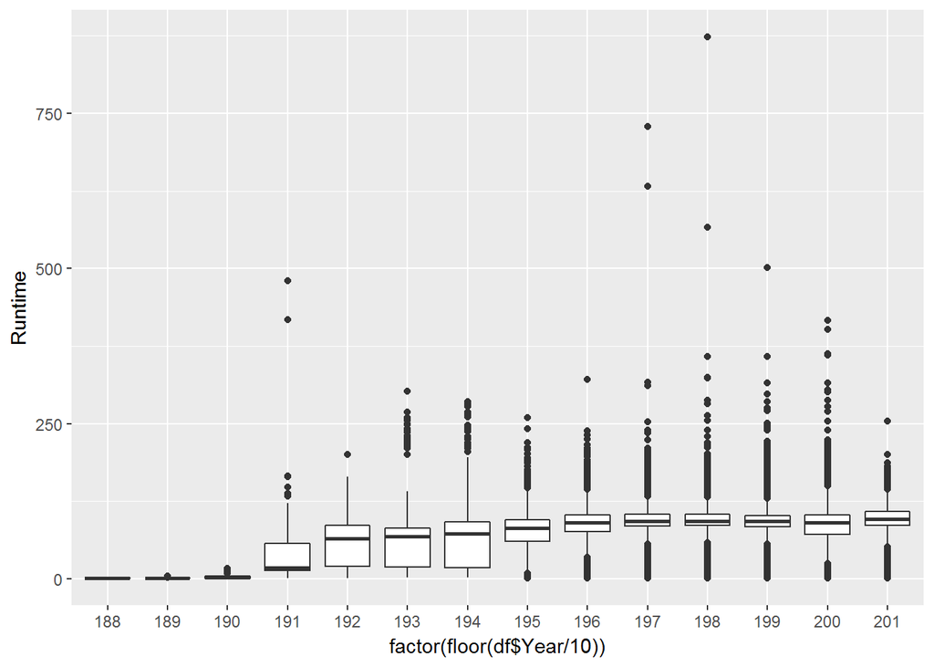

```r
plot2.2
```

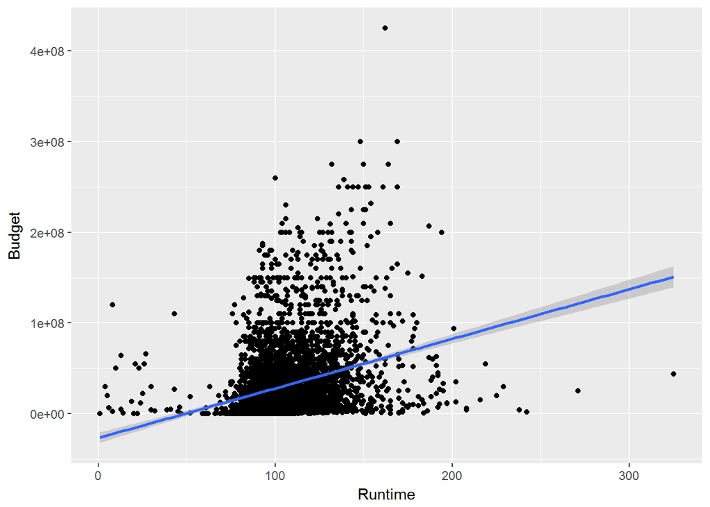

```r
plot2.3
```

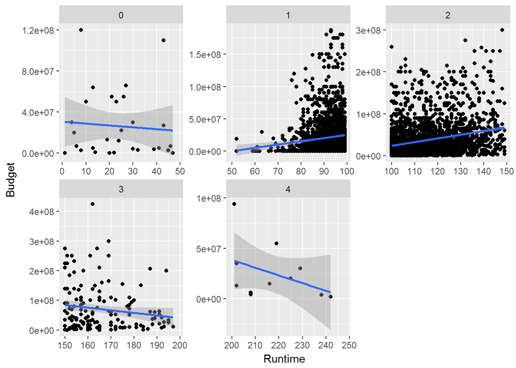

```r
plot2.4
```

```r
cor(df$Runtime, df$Budget, use="complete")
```

```
## [1] 0.2867817
```

*Feel free to insert additional code chunks as necessary.*

**Q**: Comment on the distribution as well as relationships. Are there any patterns or trends that you can observe?

**A**: 1. There is a bi-model distribution for Runtime of movies. There are more than 4000 movies have short runtime. The counts of movies decrease and increase and further decrase with runtime. More than 12000 movies have runtime between 90-100 min. There are also a few movies have very long runtime. 2. Before 1900, runtime for movies are very short. From 1900 to 1950, the runtime of movies increase, and there are big variations of runtime between movies since the interquartile ranges (IQR) are big. Since 1950, most movies have similar runtime. These movies have similar median runtime, and IQR are small. However, there are also lots of outlier points. 3. Buget is positively correlated with runtime. It is reasonalbe that longer movies need much more money to produce. However, the correlation is not very strong (ce = 0.2867). However, if you factor Runtime to < 50, 50-100, 100-150, 150-200, 200-250 min, Budget is positively correlated with Runtime when the Runtime is between 50-100 and 100-150, and negatively correlated with Runtime when it is less than 50, and larger than 150 min.

## 3. Encode `Genre` column

The column `Genre` represents a list of genres associated with the movie in a string format. Write code to parse each text string into a binary vector with 1s representing the presence of a genre and 0s the absence, and add it to the dataframe as additional columns. Then remove the original `Genre` column.

For example, if there are a total of 3 genres: Drama, Comedy, and Action, a movie that is both Action and Comedy should be represented by a binary vector <0, 1, 1>. Note that you need to first compile a dictionary of all possible genres and then figure out which movie has which genres (you can use the R `tm` package to create the dictionary).

```r
# TODO: Replace Genre with a collection of binary columns
#get a vector contains all genres
genre.all = unlist(strsplit(df$Genre, ", "))
genre.unique = unique(genre.all)
genre.unique = genre.unique[genre.unique != "N/A"]

#create new column, and insert 0 or 1
counts = c()
for(ge in genre.unique){
  colname = paste("G", ge, sep = ".")
  values = as.numeric(grepl(ge, df$Genre))
  df[, colname] = values
  counts = append(counts, sum(values))
}
df$Genre = NULL
```

Plot the relative proportions of movies having the top 10 most common genres.

```r
# TODO: Select movies from top 10 most common genres and plot their relative proportions
genre.stat = data.frame(Genre = genre.unique, Counts = counts, Proportions = counts / nrow(df))
genre.stat = genre.stat[rev(order(genre.stat$Counts)),]
genre.stat[1:10,]
```

```
##          Genre Counts Proportions
## 6        Drama  15859    0.396475
## 8       Comedy  12849    0.321225
## 4        Short   6516    0.162900
## 3      Romance   4975    0.124375
## 15      Action   4413    0.110325
## 14       Crime   4062    0.101550
## 5     Thriller   3380    0.084500
## 1  Documentary   3051    0.076275
## 11   Adventure   2928    0.073200
## 20   Animation   2788    0.069700
```

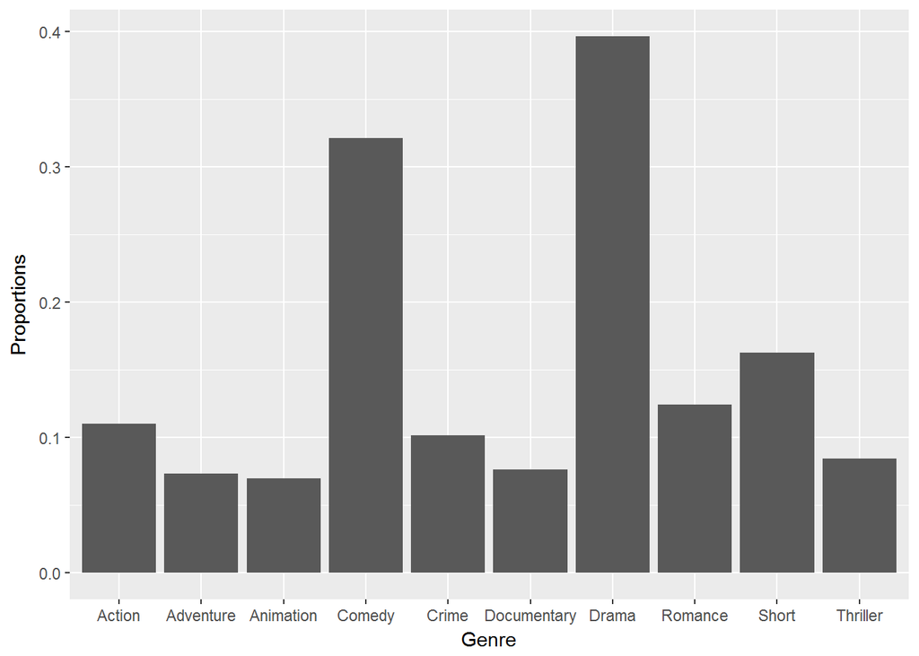

```r
plot3.1 = ggplot(genre.stat[1:10,], aes(Genre, Proportions)) +
  geom_bar(stat="identity")

plot3.1
```

Examine how the distribution of `Runtime` changes across genres for the top 10 most common genres.

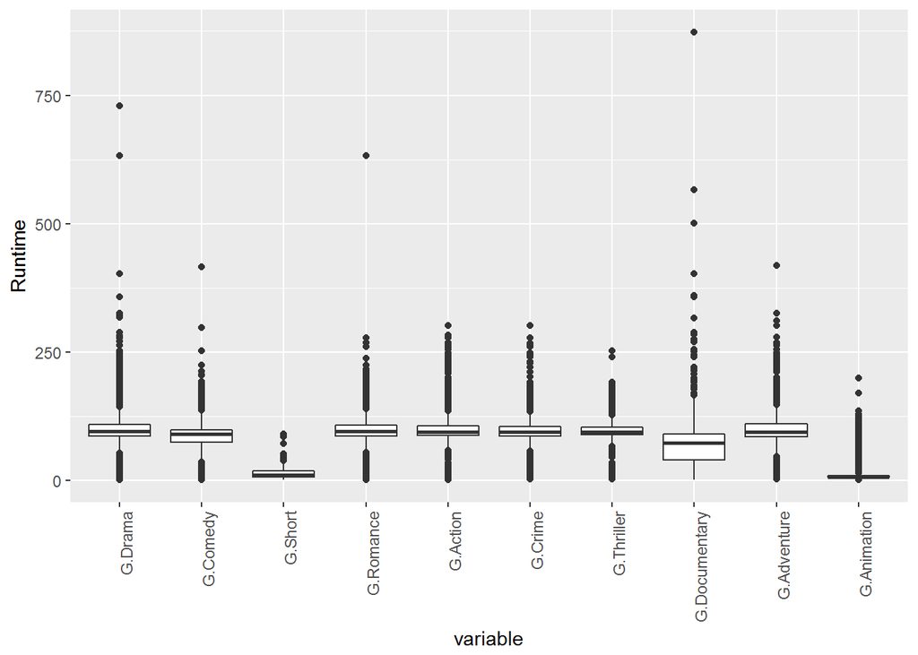

```r
# TODO: Plot Runtime distribution for top 10 most common genres
#create a new dataframe has Runtime and the top 10 Genres
df.new = df[, c(5, 44, 46, 42, 41, 53, 52, 43, 39, 49, 58)]
#melt the new dataframe
df.nm = melt(df.new, id="Runtime")

plot3.2 = ggplot(df.nm[df.nm$value == 1, ], aes(variable, Runtime)) +
  geom_boxplot() +
  theme(axis.text.x = element_text(angle = 90, hjust = 1))

plot3.2
```

**Q**: Describe the interesting relationship(s) you observe. Are there any expected or unexpected trends that are evident?

**A**: Short and Animation movies have small Runtime, and their IQRs are very narrow. Documentary movies have low median Runtime and wider IQR compared with others. The left 7 genres of movies have similar median Runtime and IQRs. There are some Drama, Romance and Documenray movies have very large Runtime.

It is expected that Short movies have small Runtime, but it is unexpected that Animation movies also have small Runtime. It is also surpring that some Drama and Documentary have very long Runtime (> 10 hours).

## 4. Eliminate mismatched rows

The dataframe was put together by merging two different sources of data and it is possible that the merging process was inaccurate in some cases (the merge was done based on movie title, but there are cases of different movies with the same title). The first sourceâs release time was represented by the column `Year` (numeric representation of the year) and the second by the column `Released` (string representation of release date).

Find and remove all rows where you suspect a merge error occurred based on a mismatch between these two variables. To make sure subsequent analysis and modeling work well, avoid removing more than 10% of the rows that have a `Gross` value present.

```r
# TODO: Remove rows with Released-Year mismatch
#get original row number
row.num1 = nrow(df)

#add column that match Year and Released
df$match = as.numeric(mapply(grepl, pattern=df$Year, x=df$Released))
df$match = df$match + as.numeric(is.na(df$Year) | is.na(df$Released))

#add column to tell whether Gross is NA
df$Gross.NA = as.numeric(is.na(df$Gross))

#new dataframe remove all dismatch rows
df.ma = df[df$match == 1, ]

#new dataframe dismatch Year and Released, but has Gross value
df.dmg = df[df$match == 0 & df$Gross.NA == 0,]

#new dataframe has Gross value
df.g = df[df$Gross.NA == 0,]

#if the row number of df.dmg large than 10% of total rows of df.g, add some rows back
set.seed(1)
df.dmg2= df.dmg[runif(nrow(df.dmg), 0.0, 1.0) > (nrow(df.g) * 0.1 / nrow(df.dmg)), ]
df = rbind(df.ma, df.dmg2)

df$match = NULL
df$Gross.NA = NULL

#row number of dataframe
row.num2 = nrow(df)

"Total rows have been removed:"
```

```
## [1] "Total rows have been removed:"
```

```r
row.num1 - row.num2
```

```
## [1] 5418
```

**Q**: What is your precise removal logic and how many rows did you end up removing?

**A**: 1. generate a dataframe (df.ma) remove all dismatch year and released rows. 2. generate another dataframe (df.dmg) that dismatch year and released, but with gross value. 3. computer the number of 10% of rows with gross value. 4. if the row number in df.dmg is larger than 10% of rows with gross value, randomly select that portion and add back to df.ma. Finally, 5418 rows have been removed.

## 5. Explore `Gross` revenue

For the commercial success of a movie, production houses want to maximize Gross revenue. Investigate if Gross revenue is related to Budget, Runtime or Genre in any way.

Note: To get a meaningful relationship, you may have to partition the movies into subsets such as short vs. long duration, or by genre, etc.

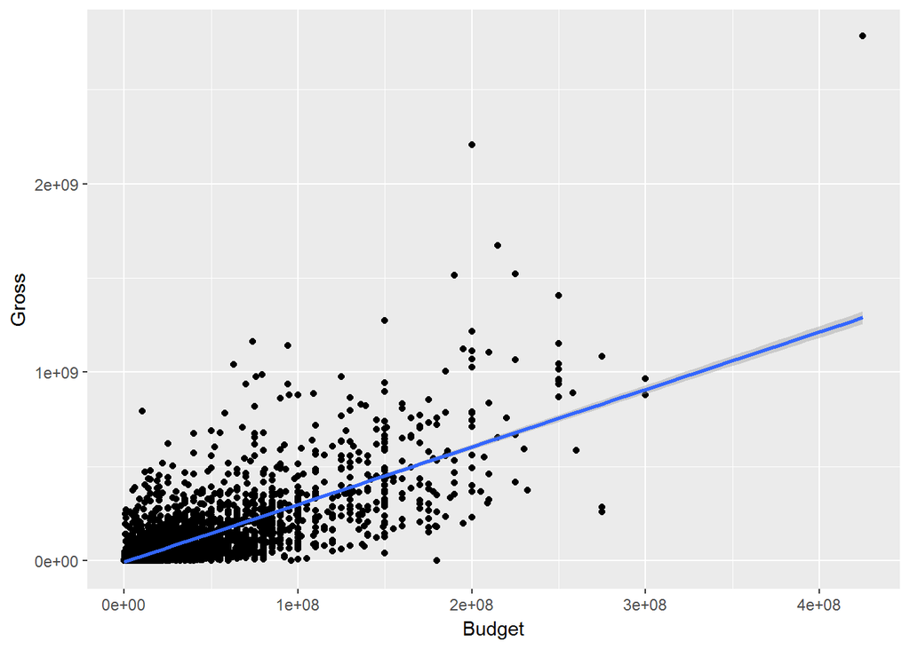

```r
# TODO: Investigate if Gross Revenue is related to Budget, Runtime or Genre
#plot Gross vs Budget
plot5.1 = ggplot(df[!is.na(df$Gross), ], aes(Budget, Gross)) +
  geom_point() +
  geom_smooth(method="lm")

#plot Gross vs Runtime
plot5.2 = ggplot(df[!is.na(df$Gross), ], aes(Runtime, Gross)) +
  geom_point() +
  geom_smooth(method="lm")

#plot Gross vs Runtime
plot5.3 = ggplot(df[!is.na(df$Gross), ], aes(Runtime, Gross)) +
  geom_point() +
  facet_wrap(~factor(floor(Runtime/50)), scales="free") +
  geom_smooth(method="lm")

#create a new dataframe to plot
df.new = df[!is.na(df$Gross), c(5, 35, 37, 39:66)]
df.nm = melt(df.new, id = c("Runtime", "Budget", "Gross"))
df.nm = df.nm[df.nm$value == 1, ]

#plot Gross vs Budget in different genres
plot5.4 = ggplot(df.nm, aes(Budget, Gross)) +
  geom_point() +
  facet_wrap(~variable, scales="free") +
  geom_smooth(method="lm")

#plot Gross vs Runtime in different genres
plot5.5 = ggplot(df.nm, aes(Runtime, Gross)) +
  geom_point() +
  facet_wrap(~variable, scales="free") +
  geom_smooth(method="lm")

#plot Gross vs Genre
plot5.6 = ggplot(df.nm, aes(variable, Gross)) +
  geom_boxplot() +
  theme(axis.text.x = element_text(angle = 90, hjust = 1))

plot5.1
```

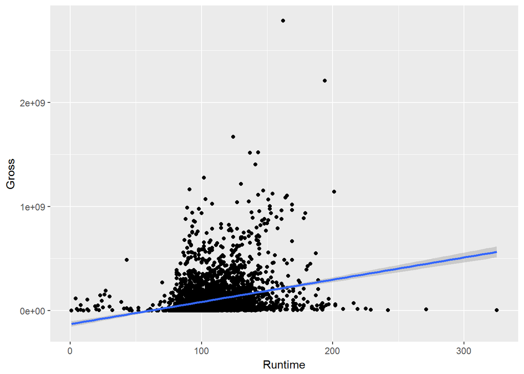

```r
plot5.2
```

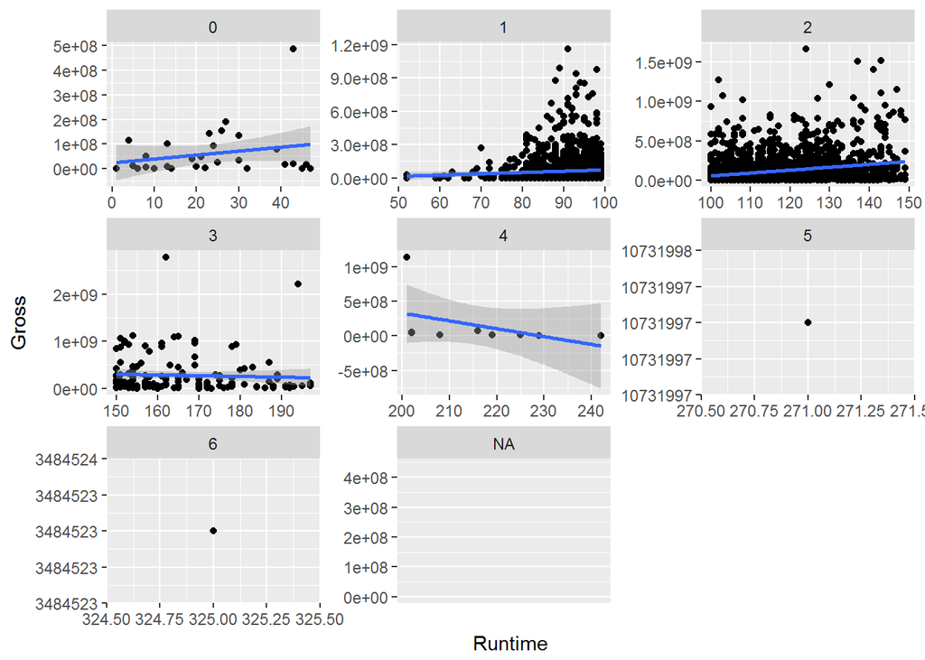

```r
plot5.3
```

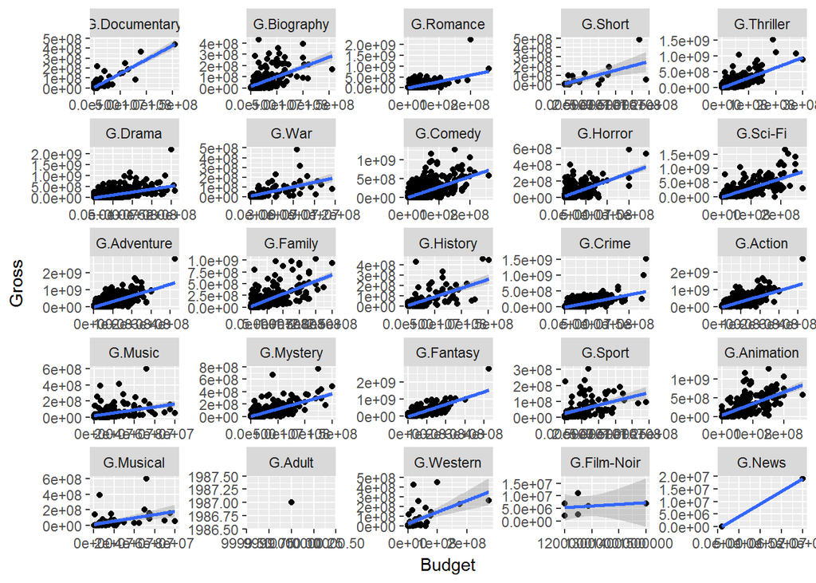

```r
plot5.4
```

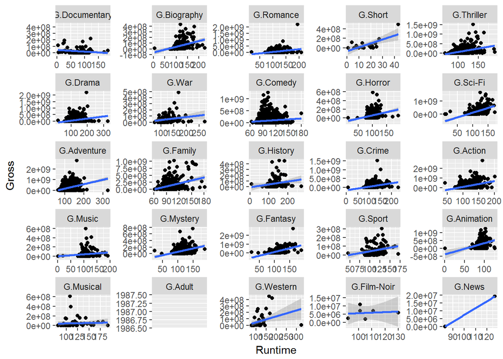

```r
plot5.5
```

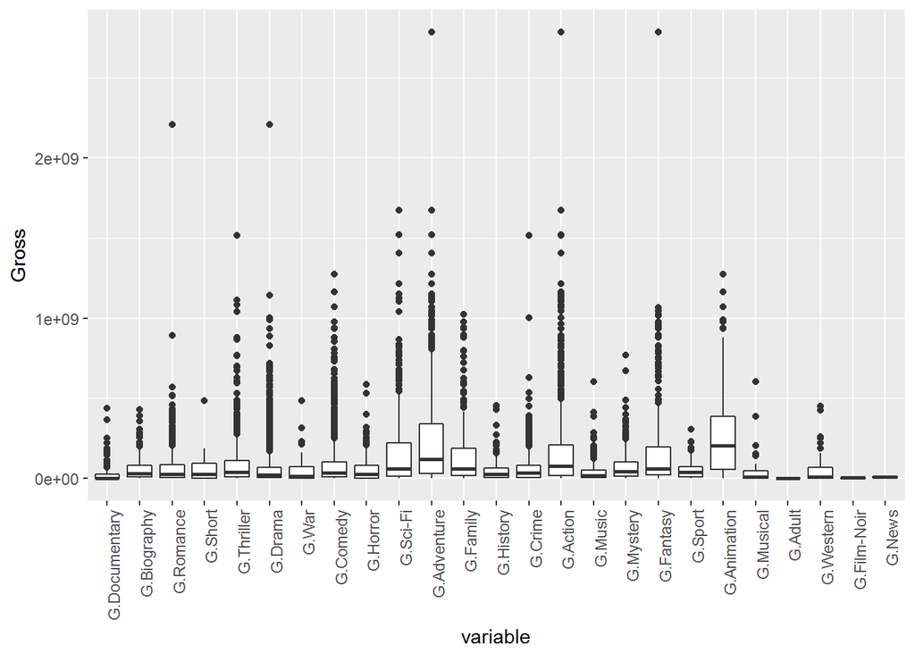

```r
plot5.6
```

**Q**: Did you find any observable relationships or combinations of Budget/Runtime/Genre that result in high Gross revenue? If you divided the movies into different subsets, you may get different answers for them - point out interesting ones.

**A**: 1. Generally, there are positive correlations between Gross and Budget, or Gross and Runtime. 2. However, for subsets of movies with different Runtime, different correlations are found. For movies with Runtime less than 150 min, there are positive correlations between Gross and Runtime, and there are no or negative correlations for movies with longer Runtime. 3. There is a positive correlation between Gross revenue and Budget in all Genres. High budget movies are more likely have high gross revenue. The solpes are different, which means it is worth to increase budget to some genres (Adventure, Fantasy, Action) of movies to get high gross revenue. 4. For some genres of movies (Sci-Fi, Adventure, Fantasy), there is a positive correlation between Gross Revenue and Runtime, while for some genres of movies (Documentary, War, Musical), the correlation is very week. 5. Animation and Adventure movies have high median Gross revenues, followed by Sci-Fi, Action, Family and Fantasy movies. There are also lots of outliers for each genres of movies, which have very high Gross revenues.

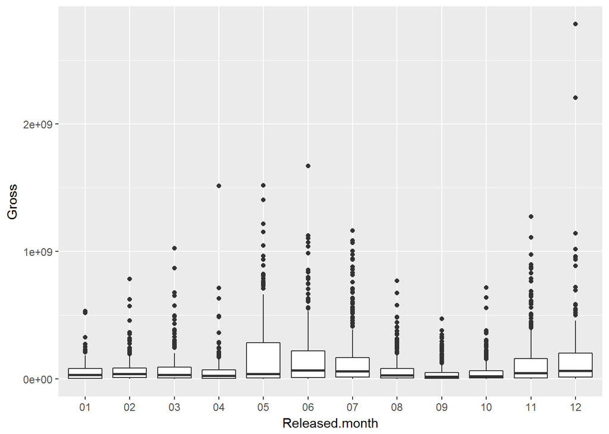

```r
# TODO: Investigate if Gross Revenue is related to Release Month
df.new = df[!is.na(df$Released), ]
df.new$Released.month = mapply(function(x) unlist(strsplit(x, "-"))[2], as.character(df.new$Released))
plot5.4 = ggplot(df.new, aes(Released.month, Gross)) +
  geom_boxplot()
plot5.4
```

## 6. Process `Awards` column

The variable `Awards` describes nominations and awards in text format. Convert it to 2 numeric columns, the first capturing the number of wins, and the second capturing nominations. Replace the `Awards` column with these new columns, and then study the relationship of `Gross` revenue with respect to them.

Note that the format of the `Awards` column is not standard; you may have to use regular expressions to find the relevant values. Try your best to process them, and you may leave the ones that don’t have enough information as NAs or set them to 0s.

```r
# TODO: Convert Awards to 2 numeric columns: wins and nominations
#count wins from a string
countWin = function(str){
  str.list = unlist(strsplit(str, " "))
  m1 = grep("win", str.list)
  return (as.numeric(str.list[m1[1] - 1]))
}

#count nominations from a string
countNomination = function(str){
  str.list = unlist(strsplit(str, " "))
  m2 = grep("nomination", str.list)
  return (as.numeric(str.list[m2[1] - 1]))
}

#add two columns for wins and nominations
df$A.win = mapply(countWin, df$Awards)
df$A.nomination = mapply(countNomination, df$Awards)

# rows had valid wins or nominations
nrow(df[!is.na(df$A.win) | !is.na(df$A.nomination), ])
```

```
## [1] 11947
```

**Q**: How did you construct your conversion mechanism? How many rows had valid/non-zero wins or nominations?

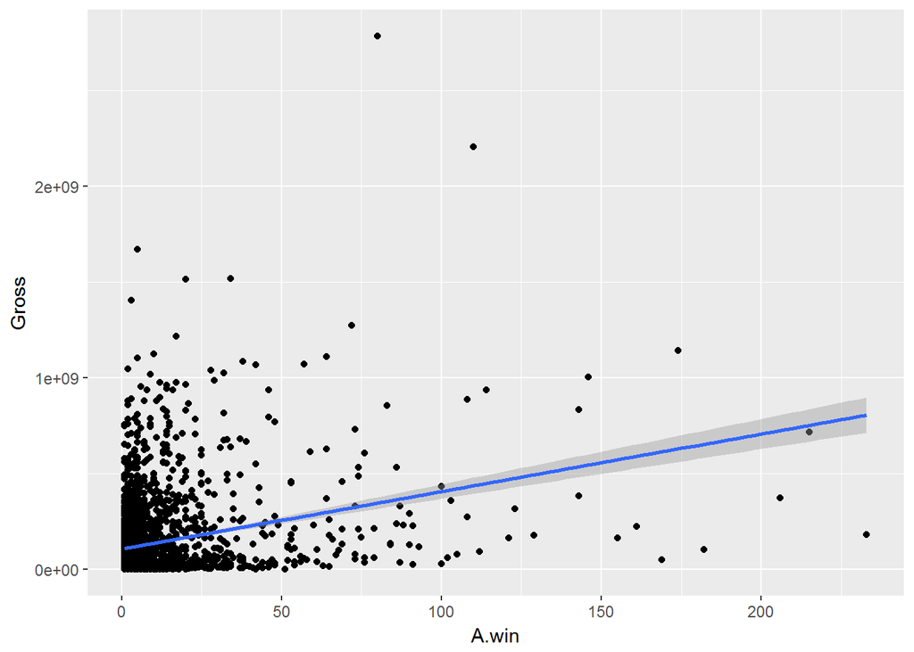

```r
# TODO: Plot Gross revenue against wins and nominations
plot6.1 = ggplot(df[!is.na(df$Gross) & !is.na(df$A.win),], aes(A.win, Gross)) +
  geom_point() +
  geom_smooth(method="lm")

plot6.2 = ggplot(df[!is.na(df$Gross) & !is.na(df$A.win),], aes(A.win, Gross)) +
  geom_point() +
  facet_wrap(~(A.win > 50), scales="free") +
  geom_smooth(method="lm")

plot6.3 = ggplot(df[!is.na(df$Gross) & !is.na(df$A.nomination),], aes(A.nomination, Gross)) +
  geom_point() +
  geom_smooth(method="lm")

plot6.4 = ggplot(df[!is.na(df$Gross) & !is.na(df$A.nomination),], aes(A.nomination, Gross)) +
  geom_point() +
  facet_wrap(~(A.nomination > 100), scales="free") +
  geom_smooth(method="lm")

plot6.1
```

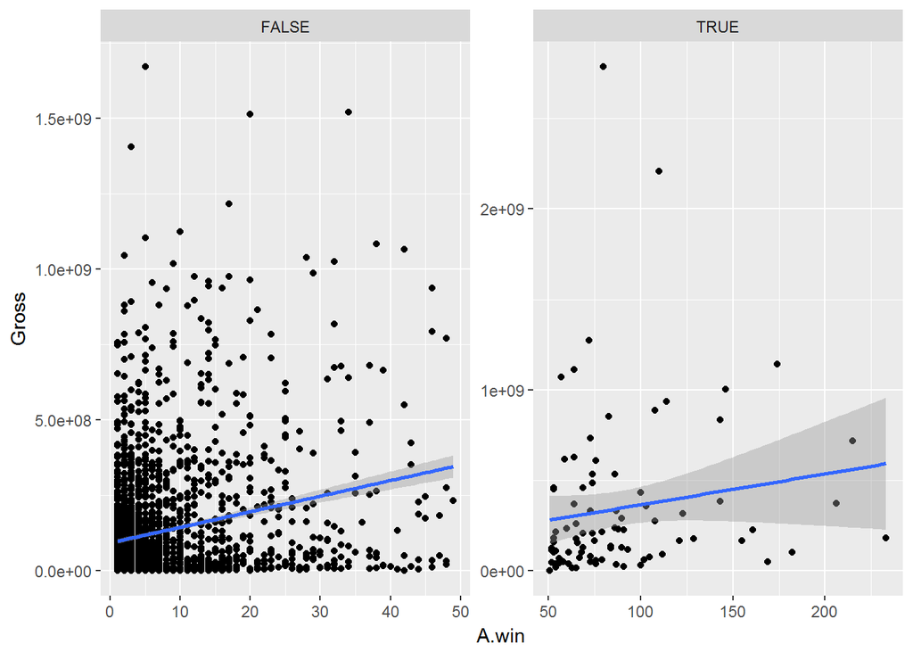

```r
plot6.2
```

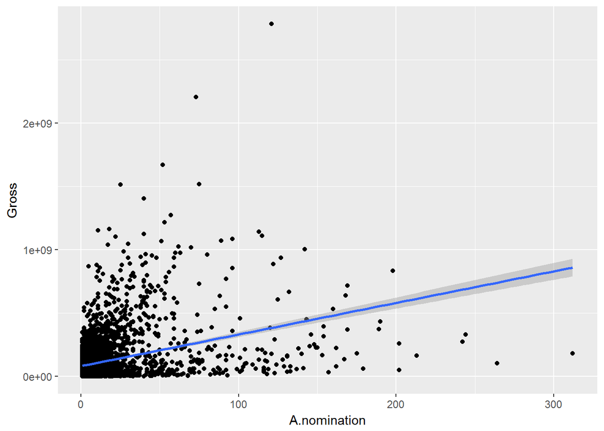

```r
plot6.3
```

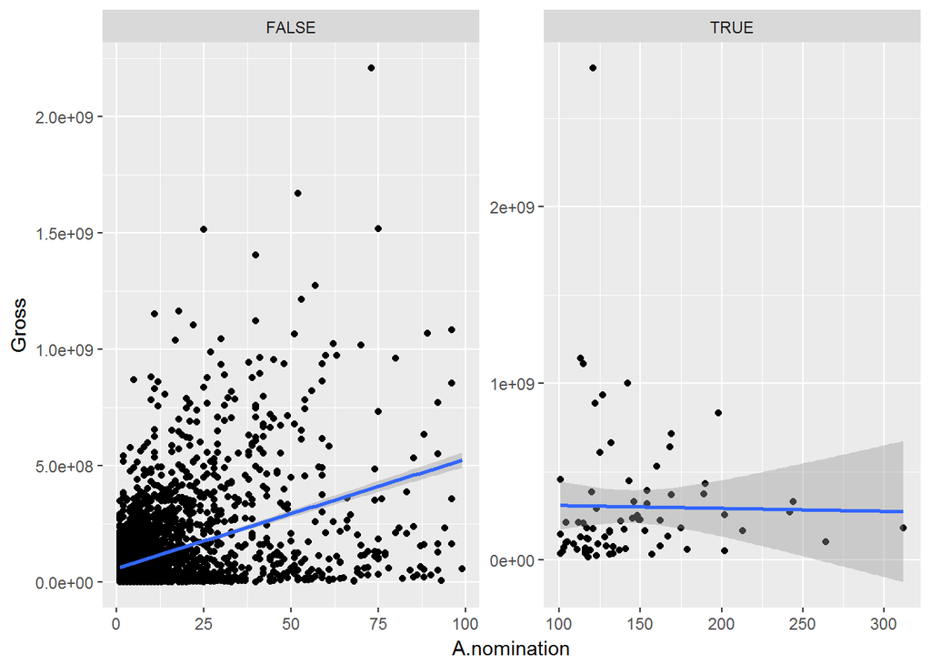

```r
plot6.4
```

**Q**: How does the gross revenue vary by number of awards won and nominations received?

**A**: The scatter plots show movies with more wins and nominations have higher gross revenues. However, this correlation decrease when wins > 50 or nominations > 100.

## 7. Movie ratings from IMDb and Rotten Tomatoes

There are several variables that describe ratings, including IMDb ratings (`imdbRating` represents average user ratings and `imdbVotes` represents the number of user ratings), and multiple Rotten Tomatoes ratings (represented by several variables pre-fixed by `tomato`). Read up on such ratings on the web (for example rottentomatoes.com/about and www.imdb.com/help/show_leaf?votestopfaq).

Investigate the pairwise relationships between these different descriptors using graphs.

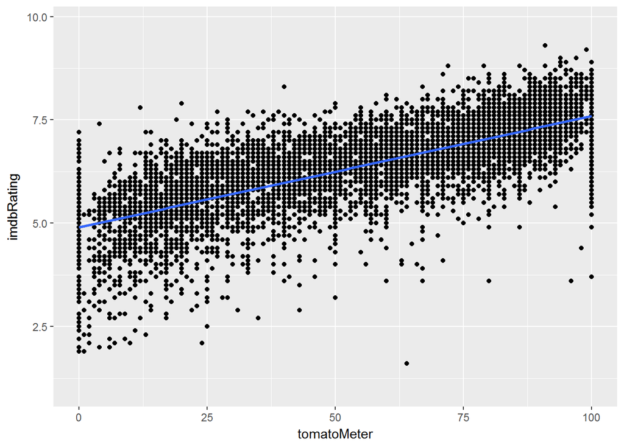

```r
# TODO: Illustrate how ratings from IMDb and Rotten Tomatoes are related
#imdbRating vs tomatoMeter
plot7.1 = ggplot(df, aes(tomatoMeter, imdbRating)) +
  geom_point() +
  geom_smooth(method="lm")

#imdbRating vs tomatoRating
plot7.2 = ggplot(df, aes(tomatoRating, imdbRating)) +
  geom_point() +
  geom_smooth(method="lm")

#imdbRating vs tomatoRotten
plot7.3 = ggplot(df, aes(tomatoRotten, imdbRating)) +
  geom_point() +
  geom_smooth(method="lm")

#imdbRating vs tomatoFresh
plot7.4 = ggplot(df, aes(tomatoFresh, imdbRating)) +
  geom_point() +
  geom_smooth(method="lm")

#imdbRating vs tomatoImage
plot7.5 = ggplot(df, aes(tomatoImage, imdbRating)) +
  geom_boxplot()


#imdbRating vs tomatoUserMeter
plot7.6 = ggplot(df, aes(tomatoUserMeter, imdbRating)) +
  geom_point() +
  geom_smooth(method="lm")

#imdbRating vs tomatoUserRating
plot7.7 = ggplot(df, aes(tomatoUserRating, imdbRating)) +
  geom_point() +
  geom_smooth(method="lm")

#imdbRating histogram
plot7.8 = ggplot(df, aes(imdbRating)) +
  geom_histogram()

plot7.9 = ggplot(df, aes(tomatoMeter)) +
  geom_histogram()

plot7.10 = ggplot(df, aes(tomatoRating)) +
  geom_histogram()

plot7.11 = ggplot(df, aes(tomatoFresh)) +
  geom_histogram()

plot7.12 = ggplot(df, aes(tomatoRotten)) +
  geom_histogram()


plot7.1
```

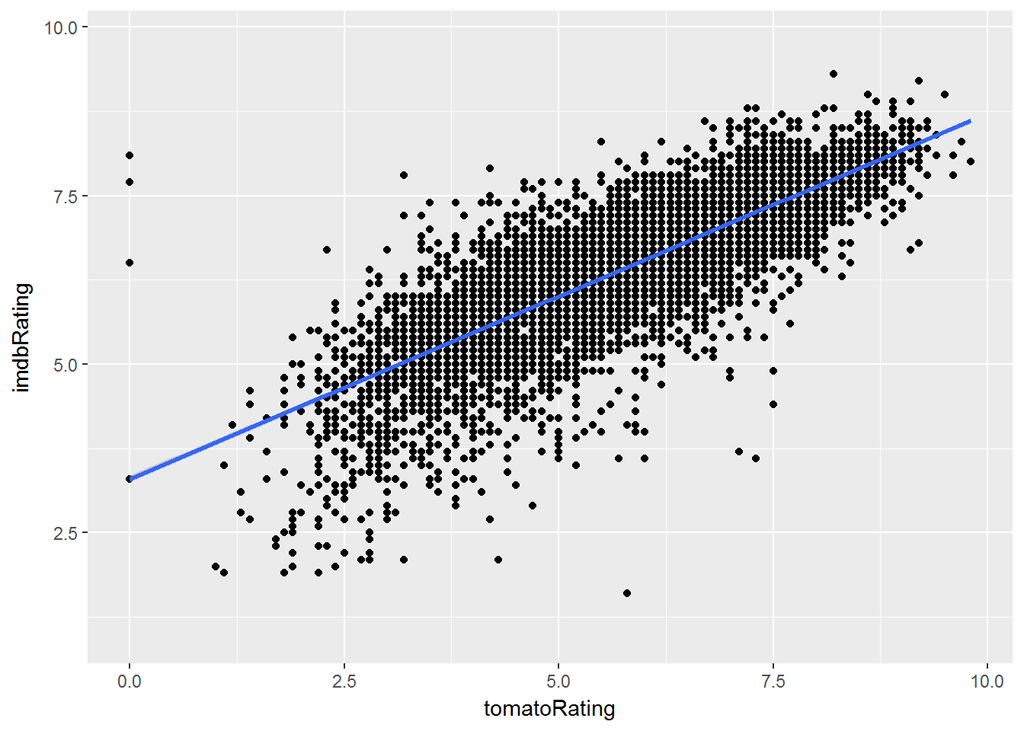

```r
plot7.2
```

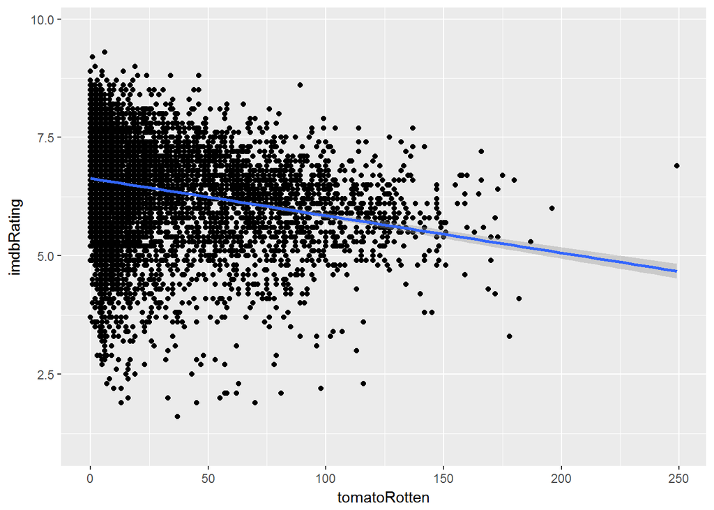

```r
plot7.3
```

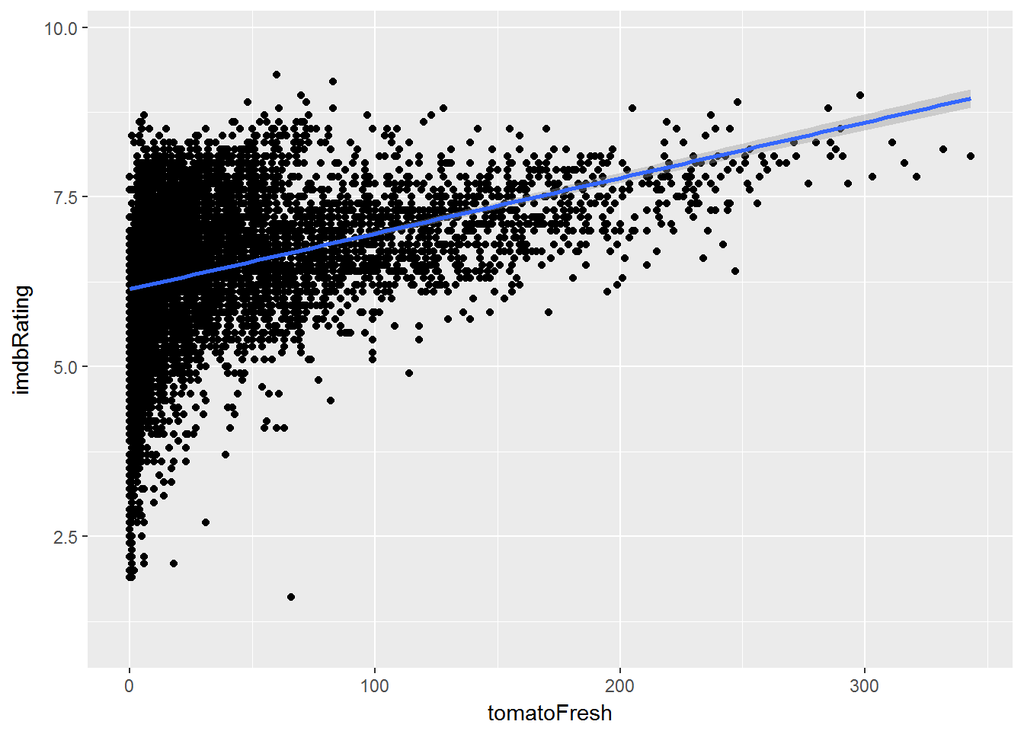

```r
plot7.4
```

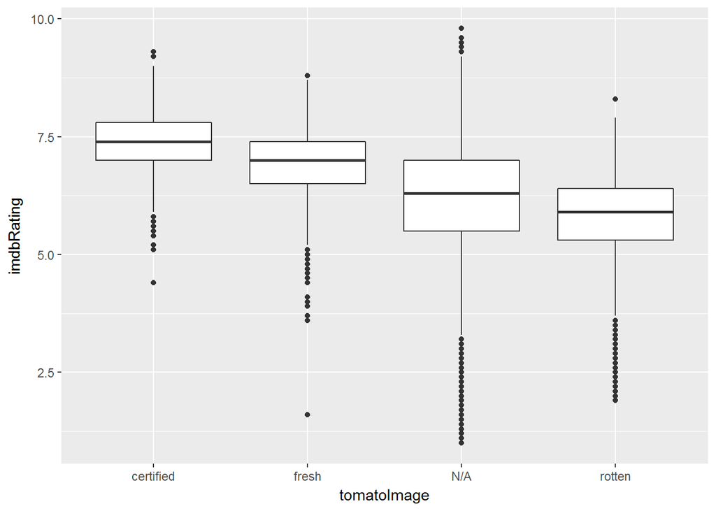

```r
plot7.5
```

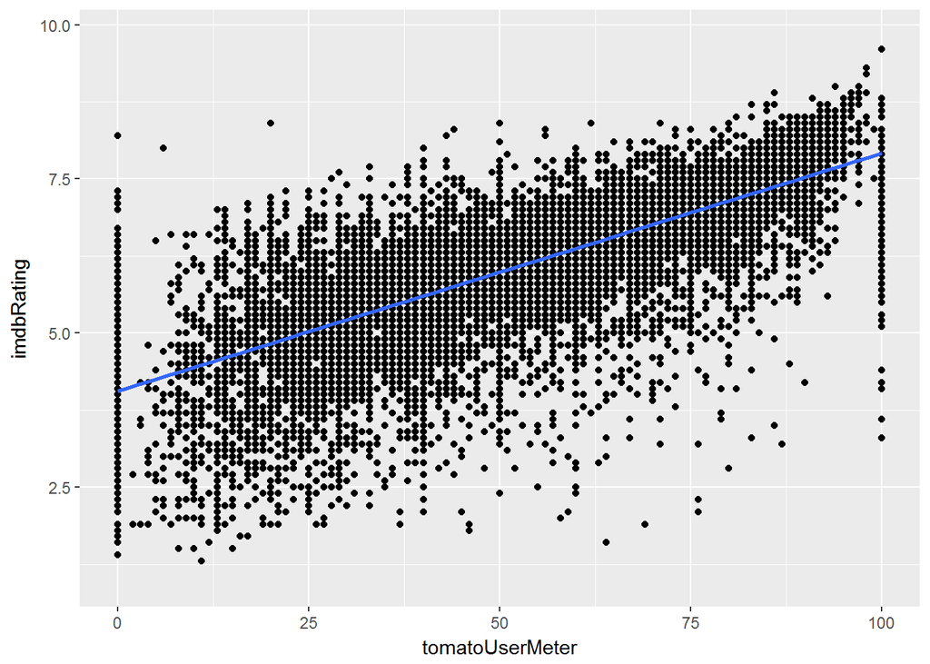

```r
plot7.6
```

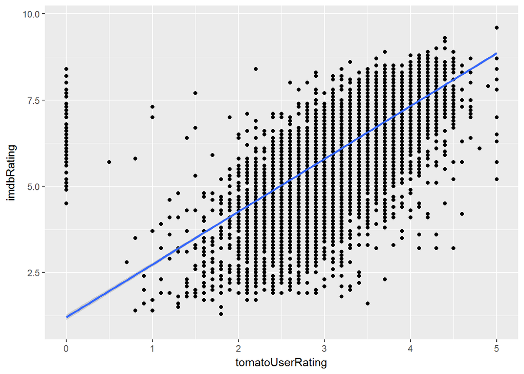

```r
plot7.7
```

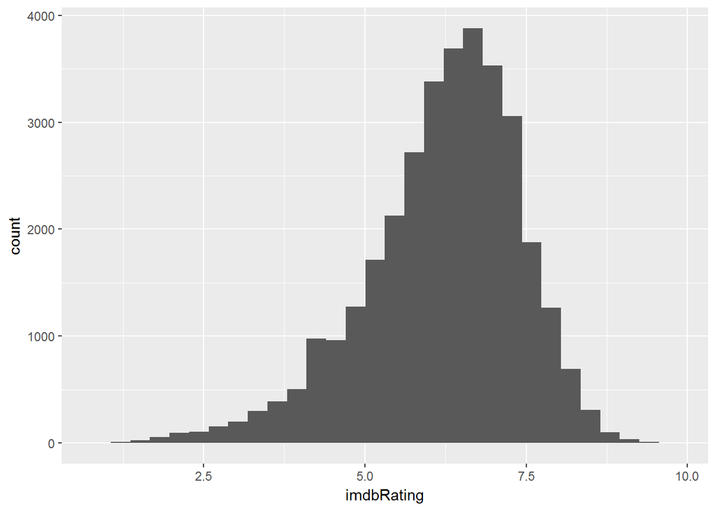

```r
plot7.8
```

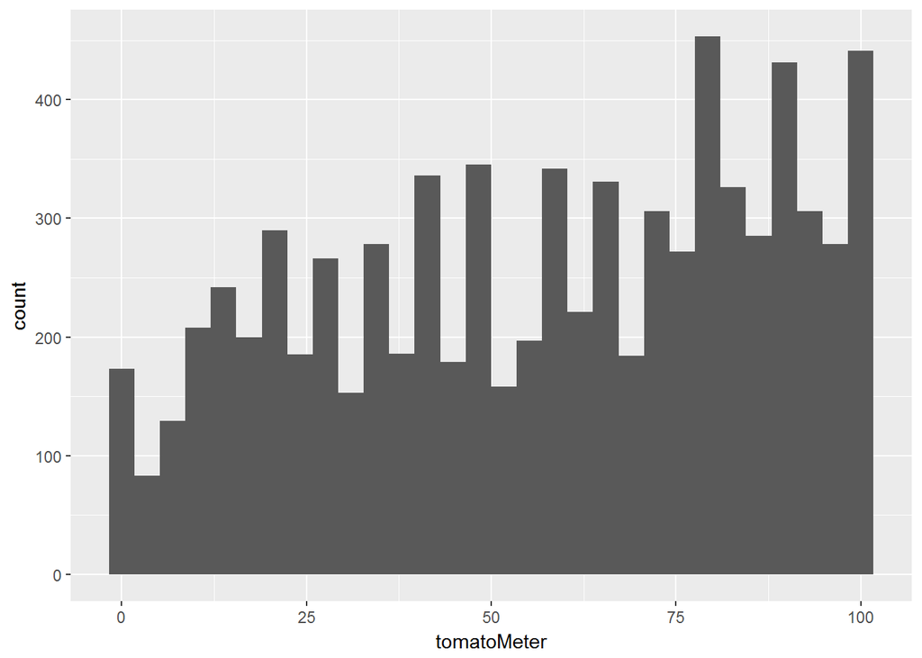

```r
plot7.9
```

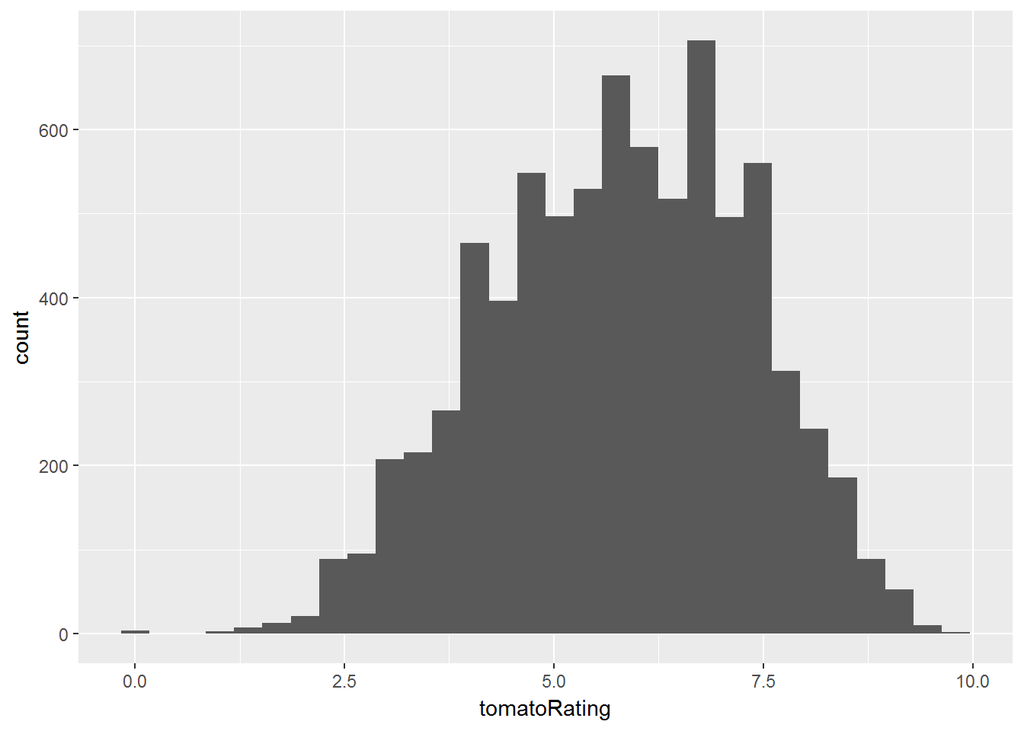

```r
plot7.10
```

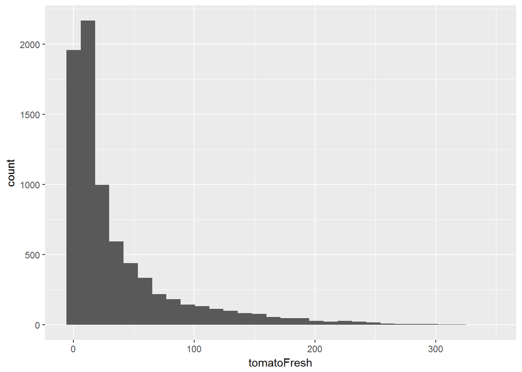

```r
plot7.11
```

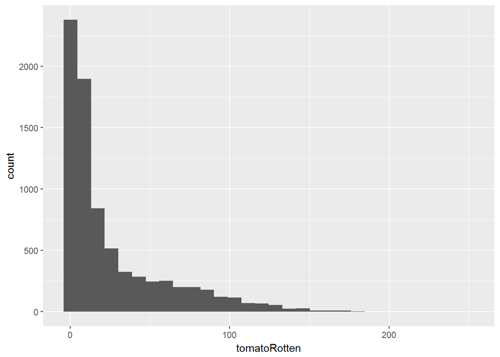

```r
plot7.12
```

**Q**: Comment on the similarities and differences between the user ratings of IMDb and the critics ratings of Rotten Tomatoes.

**A**: Similarities: there are positive correlations between imdbRating and tomatoMeter,tomatoRating, tomatoUserMeter, tomatoUserRating. The imdbRating is positive correlated with freshTomato, but negative correlated with tomatoRotten. The box plot of imdbRating vs tomatoImage shows certified movies have highest imdbRating, followed by fress, N/A, and rotten.